# healthUtilisation

Alessio Navarra

2022-10-09

## Introduction

This is the health care utilisation dataset.

This dataset includes statistics comparing different countries’ level of health care use in terms of prevention, immunisation, screening, diagnostics exams, consultations, in-patient utilisation, average length of stay, diagnostic categories, acute care, in-patient care, discharge rates, transplants, dialyses, ICD-9-CM. The data is comparable with respect to units of measures such as days, percentages, population, number per capita, procedures, and available beds.

*Keywords*: average length of stay, diagnostic categories, discharge rates, screening, transplants, dialyses, in-patient care, consultations, in-patient utilisation, diagnostics exams, ICD-9-CM, statistics, immunisation, prevention, acute care

```r
dataset <- read.csv("dataset.csv")
summary(dataset)
```

```
##      VAR              Variable             UNIT             Measure
##  Length:225039      Length:225039      Length:225039      Length:225039
##  Class :character   Class :character   Class :character   Class :character
##  Mode  :character   Mode  :character   Mode  :character   Mode  :character
##
##
##
##
##      COU              Country               YEA            Year
##  Length:225039      Length:225039      Min.   :2010   Min.   :2010
##  Class :character   Class :character   1st Qu.:2012   1st Qu.:2012
##  Mode  :character   Mode  :character   Median :2015   Median :2015
##                                        Mean   :2015   Mean   :2015
##                                        3rd Qu.:2018   3rd Qu.:2018
##                                        Max.   :2021   Max.   :2021
##
##      Value            Flag.Codes           Flags
##  Min.   :        0   Length:225039      Length:225039
##  1st Qu.:        8   Class :character   Class :character
##  Median :       93   Mode  :character   Mode  :character
##  Mean   :    95611
##  3rd Qu.:     2490
##  Max.   :265027000
##  NA's   :8
```

## Exploratory analysis

Let’s find out what is included in the dataset. What are the variables captured?

```r
unique(dataset$Variable)
```

```
##   [1] "Immunisation: Hepatitis B"
##   [2] "Immunisation: Influenza"
##   [3] "Immunisation: Diphtheria, Tetanus, Pertussis"
##   [4] "Immunisation: Measles"
##   [5] "Dentists consultations (in all settings)"
##   [6] "Doctors consultations (in all settings)"
##   [7] "Computed Tomography exams, total"
##   [8] "Magnetic Resonance Imaging exams, total"
##   [9] "Computed Tomography exams, in hospitals"
##  [10] "Computed Tomography exams, in ambulatory care"
##  [11] "Magnetic Resonance Imaging exams, in hospitals"
##  [12] "Magnetic Resonance Imaging exams, in ambulatory care"
##  [13] "All causes"
##  [14] "Infectious and parasitic diseases"
##  [15] "Intestinal infectious diseases except diarrhoea"
```

[output cut: 186 more lines]

Let’s try picking a variable and visualising differences between countries with a plot

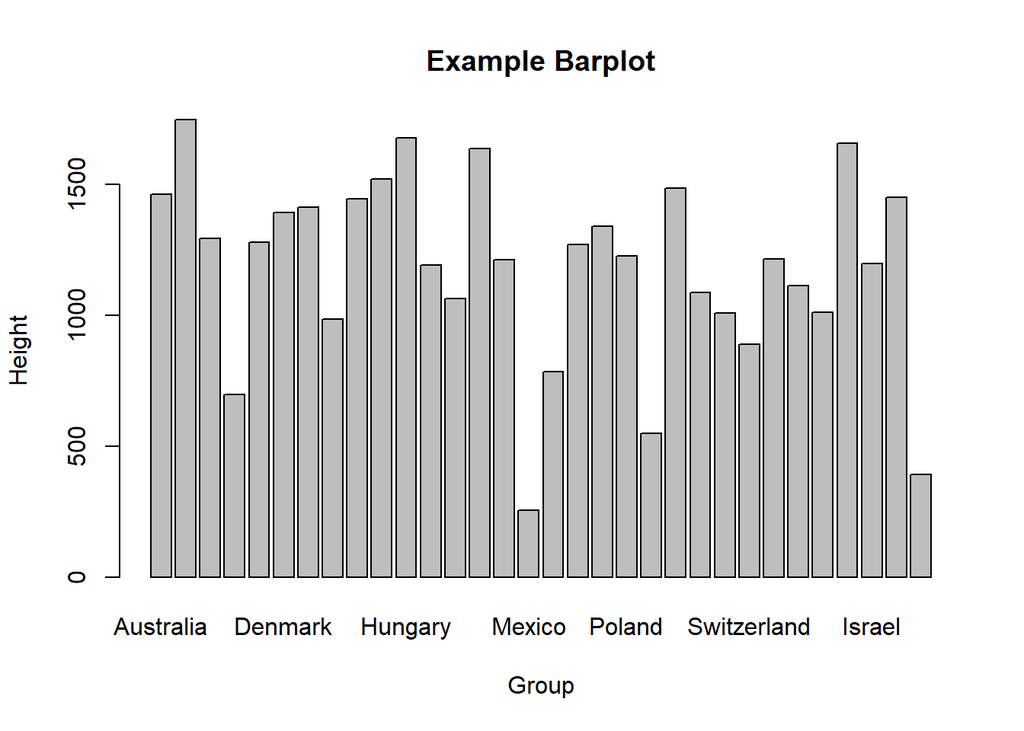

```r
respiratory <- dataset[dataset$Variable == "Diseases of the respiratory system", ]
respiratory2010 <- respiratory[respiratory$Year == 2010, ]
respiratory2010 <- respiratory2010[respiratory2010$Measure == "Per 100 000 population", ]

Resp_per100 <- data.frame(Country = respiratory2010$Country, Value = respiratory2010$Value)

barplot(height = respiratory2010$Value,
        names.arg = respiratory2010$Country,
        main = "Example Barplot",
        xlab = "Group",
        ylab = "Height")
```

Having a look at doctors consultation

```r
consultations <- dataset[dataset$Variable == "Doctors consultations (in all settings)", ]
consultations2010 <- consultations[consultations$Year == 2010, ]
```

Combining the 2 dataframes, shows that country with more incidence of respiratory diseases, also have more consultations

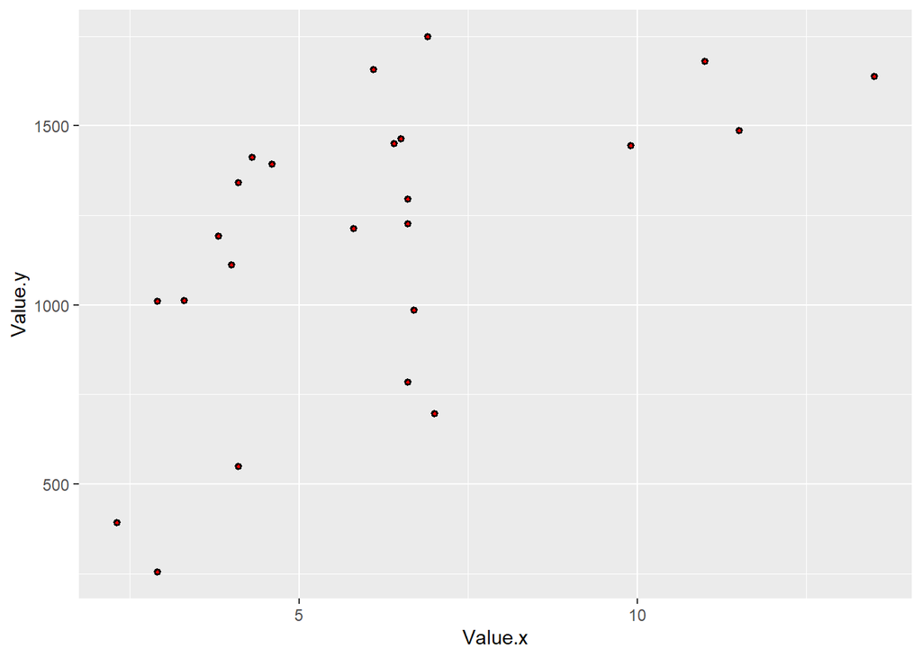

```r
combined <- merge(consultations2010, respiratory2010, by = "Country", all.x=FALSE, all.y=FALSE)
combined <- combined[,c("Country", "Value.x", "Value.y")]

library(ggplot2)
ggplot(combined, aes(x=Value.x, y=Value.y)) +
  geom_point(shape = 21, size = 1, stroke = 1, color = 'black', fill='red')
```

UK data on several conditions

```r
uk <- dataset[dataset$Country == "United Kingdom", ]
uk <- uk[uk$Measure == "Per 100 000 population",]
septicaemia <- uk[uk$Variable == "Septicaemia",]
diabetes <- uk[uk$Variable == "Diabetes mellitus",]
mi <- uk[uk$Variable == "Acute myocardial infarction",]
hf <- uk[uk$Variable == "Heart failure",]
copd <- uk[uk$Variable == "Chronic obstructive Pulmonary disease and bronchiectasis",]

library(tidyverse)
df3 <- bind_rows(copd, mi, diabetes)
```

Showing plots

```r
library(gridExtra)
```

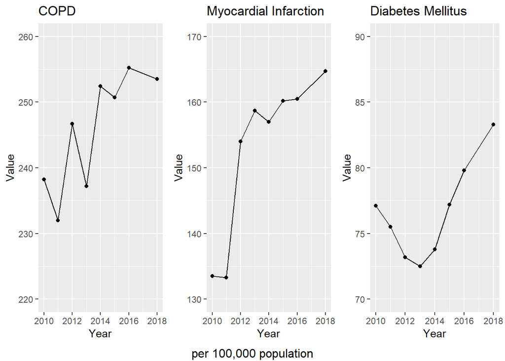

```r
p1 <- ggplot(copd, aes(x=Year, y=Value)) + labs(title = "COPD") + geom_line() + geom_point() + ylim(220, 260)
p2 <- ggplot(mi, aes(x=Year, y=Value)) + labs(title = "Myocardial Infarction") + geom_line() + geom_point() + ylim(130, 170)
p3 <- ggplot(diabetes, aes(x=Year, y=Value)) + labs(title = "Diabetes Mellitus") + geom_line() + geom_point() + ylim(70, 90)
grid.arrange(p1, p2, p3, nrow = 1,
             bottom = "per 100,000 population")
```

Doctors per 1,000 population

```r
doctors <- read_csv("doctors.csv")
```

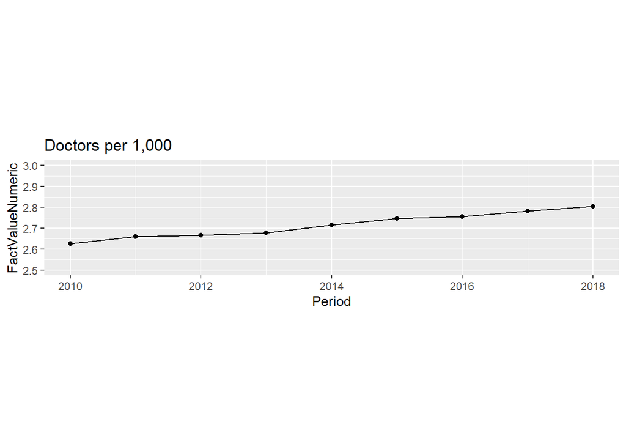

```r
doctors <- doctors[doctors$Period <= 2018,]
doctors$FactValueNumeric <- doctors$FactValueNumeric / 10
docplot <- ggplot(doctors, aes(x=Period, y=FactValueNumeric)) + labs(title = "Doctors per 1,000") + geom_line() + geom_point() + ylim(2.5, 3.0) + xlim(2010,2018) + theme(aspect.ratio = 0.2)
docplot
```